# Assignment 5: Mixed models

Marton Kovacs

# Introduction

This assignment is related to the previous lab assignment concerning perioperative pain and its psychological and hormonal predictors. Just like previously, you will set up linear model to predict postoperative pain after wisdom tooth surgery, but this time you will have to also take into account the fact that there is clustering in the data.

Your research paper on the effect of the psychological and hormonal predictors of postoperative pain was so successful, that you managed to secure research funding for a multi-site replication study. Here your collaborators collect data in the same way you did in the original study at 20 different hospital sites. The goal of the study is to increase the generalizability of your findings. You would like to assess the model coefficients and the overall predictive efficiency of the predictors in your model.

As a reminder, here is the protocol for data collection: “You have collected data from adults who were scheduled to undergo surgical extraction of the third mandibular molar (wisdom tooth surgery). Patients filled out a form in the waiting room before their surgery. The form contained questions about their sex, age, and weight, and psychological questionnaires assessing anxiety, pain catastrophizing, and mindfulness (see descriptions below). You also got blood samples and saliva samples from participants in the waiting room 5 minutes before their operations to determine the serum (a component of the blood) and salivary cortisol levels of participants. Participants were contacted 5 hours after the surgery to see how much pain they were experiencing. The **level of pain** at that moment was recorded using a numerical rating scale using a **scale of 0 to 10**, where 0 means “no pain” and 10 means “worst pain I can imagine”.

**The State Trait Anxiety Inventory:** T measures trait anxiety on a scale of 20 to 80, higher scores mean higher anxiety. Anxiety has been found in many studies to positively correlate with the level of pain experienced. This is **variable STAI_trait** in the dataset.

**The Pain Catastrophizing Scale** measures the extent of pain catastrophizing, which is characterized by a tendency to magnify the threat value of a pain stimulus and to feel helpless in the presence of pain, as well as by a relative inability to prevent or inhibit pain-related thoughts in anticipation of, during, or following a painful event. The total score on this scale ranges from 0 to 52, higher scores mean higher catastrophizing. Pain catastrophizing is one of the well-established predictors of clinical pain. This is **variable pain_cat** in the dataset.

**The Mindful Attention Awareness Scale (MAAS)** measures dispositional mindfulness, which may be described as a tendency to turn attention to present-moment experiences in an open, non-judgemental way. The MAAS total score ranges from 1 to 6 (an average of the item scores), with higher scores representing higher dispositional mindfulness. Trait mindfulness has been theorized to serve as a protective factor against pain, as the individual would be more objective about their pain experience and tend to associate less discomfort, despair, and hopelessness to the pain-related sensations. This is **variable mindfulness** in the dataset.

**Cortisol** is a stress hormone associated with acute and chronic stress. Cortisol levels are thought to be positively associated with pain experience. Cortisol can be **measured from both blood and the saliva**, although, serum cortisol is often regarded in medical research as more reliably related to stress (serum is a component of the blood plasma). These are **variables cortisol_serum**, and **cortisol_saliva** in the dataset.”

# Datasets

You will need two datasets for this assignment, datafile A and B. You can load them from the ‘data/’ folder.

# Task

First, fit a linear mixed model to estimate postoperative pain on datafile A. You should use the same fixed effect predictors as you used in your final model in the 3 assignment. (If you did not do that assignment, use the following predictors: age, sex, STAI, pain catastrophizing, mindfulness, and serum cortisol.) Importantly, the model has to account for the clustering of the data in different hospital sites. We have no reason to assume that the effects of the different predictors would be different in the different hospitals, so fit a random intercept model including the random intercept of hospital-ID. Once the model is built, note the model coefficients and the confidence intervals of the coefficients for all fixed effect predictors, and compare them to the ones obtained in the 3 assignment.

Also, compute the variance explained by the fixed effect predictors using marginal R<sup>2</sup>, and the variance explained by the fixed and random effect terms combined using conditional R<sup>2</sup>. Now use the model coefficients obtained on data file A to predict pain in datafile B.

**IMPORTANT:** Do not fit the regression models on data file B (don’t re-train your models), just use the regression equation you derived based on datafile A. These regression equations should be applied on the new data (datafile B), to predict pain.

Now compute the variance explained by the model on datafile B. You can do this by using the formula: **1 - (RSS / TSS) = R^2**. Compare this R<sup>2</sup> to the marginal and conditional R<sup>2</sup> values computed for the model on datafile A.

# What to report

Report the model coefficients and the confidence intervals of the coefficients for each fixed effect predictor obtained on data file A in a table.

Report the variance components for the fixed effects, the random intercept, and the residuals (from the model on data file A). Also report the marginal R<sup>2</sup> and the conditional R<sup>2</sup> squared obtained from the model on data file A, and the observed R<sup>2</sup> of this model for data file B.

# What to discuss

Compare the model coefficients and the confidence intervals observed in this assignment and the assignment for Lab 2 and discuss what you think the differences or similarities mean.

# Solution

## Read the data

Read the datasets used in this assignment. Pay attention to the extensions of the datafiles.

```r
# Reading the datasets from link
dataset_a <- read_sav("https://github.com/HujberAL/Fall-2024/raw/refs/heads/main/data/assignment_4_dataset_A_.sav")
dataset_b <- read_sav("https://github.com/HujberAL/Fall-2024/raw/refs/heads/main/data/assignment_4_dataset_B_.sav")
```

## Exploratory data analysis

Run an exploratory data analysis (EDA) to investigate the dataset.

```r
EDA_data_a <- dataset_a %>%
  gather(key = "pred", value = "value", age, STAI_trait, pain_cat, mindfulness, cortisol_serum, cortisol_saliva) # To run the analysis, reshape the dataset from wide to long
```

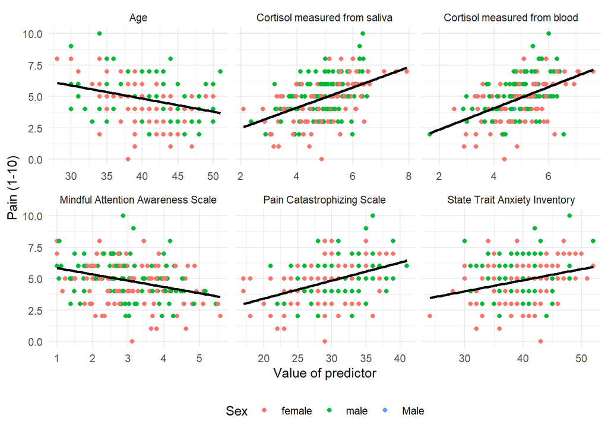

```r
titles_for_EDA <- c("age" = "Age",
                    "STAI_trait" = "State Trait Anxiety Inventory",
                    "pain_cat" = "Pain Catastrophizing Scale",
                    "mindfulness" = "Mindful Attention Awareness Scale",
                    "cortisol_serum" = "Cortisol measured from blood",
                    "cortisol_saliva" = "Cortisol measured from saliva"
                    ) # Custom titles for plots

ggplot(EDA_data_a, aes(x = value, y = pain)) + # Connection of each predictor with pain in one plot
  geom_point(aes(color = sex)) +  # Scatter plot with points colored by sex
  geom_smooth(method = "lm", se = FALSE, color = "black") +  # Linear regression line to see the connection
  facet_wrap(~ pred, scales = "free_x", labeller = labeller(pred = titles_for_EDA)) +  # Facet by the pred variable
  labs(x = "Value of predictor", y = "Pain (1-10)", color = "Sex") + # Captions
  theme_minimal() + # Minimalistic theme
  theme(legend.position = "bottom")  # Move legend to the bottom
```

```r
EDA_data_b <- dataset_b %>%
  gather(key = "pred", value = "value", age, STAI_trait, pain_cat, mindfulness, cortisol_serum, cortisol_saliva) # To run the analysis, reshape the dataset from wide to long
```

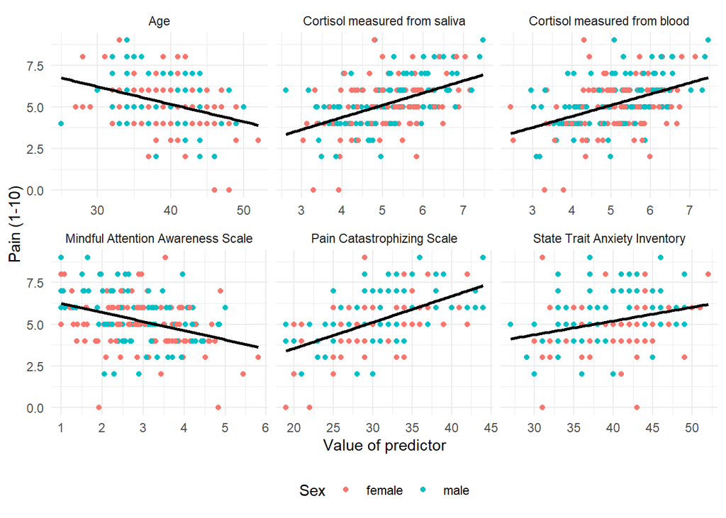

```r
ggplot(EDA_data_b, aes(x = value, y = pain)) + # Connection of each predictor with pain in one plot
  geom_point(aes(color = sex)) +  # Scatter plot with points colored by sex
  geom_smooth(method = "lm", se = FALSE, color = "black") +  # Linear regression line to see the connection
  facet_wrap(~ pred, scales = "free_x", labeller = labeller(pred = titles_for_EDA)) +  # Facet by the pred variable
  labs(x = "Value of predictor", y = "Pain (1-10)", color = "Sex") + # Captions
  theme_minimal() + # Minimalistic theme
  theme(legend.position = "bottom")  # Move legend to the bottom
```

## Correct coding errors

If you find values in the dataset during the EDA, that are not correct based on the provided descriptions of the variables of the dataset please correct them here.

```r
dataset_a <- dataset_a %>%
  mutate(sex = str_replace(sex, "Male", "male")) # Replacing the wrong non-numeric value"

# Checking the thresholds for dataset A
dataset_a$pain <- ifelse(dataset_a$pain < 0 | dataset_a$pain > 10, NA, dataset_a$pain)
dataset_a$STAI_trait <- ifelse(dataset_a$STAI_trait < 20 | dataset_a$STAI_trait > 80, NA, dataset_a$STAI_trait)
dataset_a$pain_cat <- ifelse(dataset_a$pain_cat < 0 | dataset_a$pain_cat > 52, NA, dataset_a$pain_cat)
dataset_a$mindfulness <- ifelse(dataset_a$mindfulness < 1 | dataset_a$mindfulness > 6, NA, dataset_a$mindfulness)

# Checking the thresholds for dataset B
dataset_b$pain <- ifelse(dataset_b$pain < 0 | dataset_b$pain > 10, NA, dataset_b$pain)
dataset_b$STAI_trait <- ifelse(dataset_b$STAI_trait < 20 | dataset_b$STAI_trait > 80, NA, dataset_b$STAI_trait)
dataset_b$pain_cat <- ifelse(dataset_b$pain_cat < 0 | dataset_b$pain_cat > 52, NA, dataset_b$pain_cat)
dataset_b$mindfulness <- ifelse(dataset_b$mindfulness < 1 | dataset_b$mindfulness > 6, NA, dataset_b$mindfulness)
```

## Creating the model:

```r
# Creating the linear mixed model
model_a <- lmer(pain ~ age + sex + STAI_trait + pain_cat + mindfulness + cortisol_serum + (1 | hospital), data = dataset_a)

model_a_sum <- summary(model_a) # Summarizing for extraction of data to be reported
```

## Creating the values to report:

```r
coef_model_a <- model_a_sum$coefficients # Get the model coefficients

coef_table <- data.frame( # Data in data frame to be reported
  Predictor = rownames(coef_model_a),
  Estimate = coef_model_a[, "Estimate"],
  `Std. Error` = coef_model_a[, "Std. Error"],
  `t value` = coef_model_a[, "t value"]
)

coef_table$p.value <- 2 * (1 - pnorm(abs(coef_table$Estimate / coef_table$Std..Error))) # Calculating the p value


conf_int_model_a <- confint(model_a, level = 0.95) # Calculating confidence intervals
```

```
## Computing profile confidence intervals ...
```

```r
CI_data <- conf_int_model_a[-c(1, 2), ] # Get the part what we need (first two rows not needed)

coef_table$Lower_CI <- CI_data[2, 1] # CI-s to data frame
coef_table$Upper_CI <- CI_data[2, 2]

print(coef_table) # Report the data
```

```
##                     Predictor    Estimate Std..Error     t.value      p.value
## (Intercept)       (Intercept)  3.50230566 1.38045391  2.53706815 1.117852e-02
## age                       age -0.05439985 0.01981822 -2.74494051 6.052187e-03
## sexmale               sexmale  0.29754490 0.19045999  1.56224357 1.182306e-01
## STAI_trait         STAI_trait  0.00143700 0.02385148  0.06024782 9.519583e-01
## pain_cat             pain_cat  0.03688499 0.02863292  1.28820220 1.976756e-01
## mindfulness       mindfulness -0.26244090 0.10064662 -2.60754796 9.119329e-03
## cortisol_serum cortisol_serum  0.61001003 0.11426020  5.33877943 9.357440e-08
##                   Lower_CI    Upper_CI
## (Intercept)    -0.09363796 -0.01620546
## age            -0.09363796 -0.01620546
## sexmale        -0.09363796 -0.01620546
## STAI_trait     -0.09363796 -0.01620546
## pain_cat       -0.09363796 -0.01620546
## mindfulness    -0.09363796 -0.01620546
## cortisol_serum -0.09363796 -0.01620546
```

## R² values in model A:

```r
r2_results <- r2(model_a) # Calculate marginal and conditional R² for the mixed model

print(r2_results) # Report the results
```

```
## # R2 for Mixed Models
##
##   Conditional R2: 0.436
##      Marginal R2: 0.317
```

## Prediction of pain:

```r
dataset_b$predicted_pain <- predict(model_a, newdata = dataset_b, re.form = NA) # Prediction of pain in dataset B from fixed effects coef from model A

print(dataset_b$predicted_pain) # Report the result
```

```
##        1        2        3        4        5        6        7        8
## 7.933631 4.366307 5.737109 3.688298 4.530486 3.622731 6.004193 4.147539
##        9       10       11       12       13       14       15       16
## 5.609978 6.061013 4.486859 3.171614 5.549481 3.063691 4.757941 4.090421
##       17       18       19       20       21       22       23       24
## 5.822487 6.089844 4.544618 4.404710 3.555569 5.667272 4.610015 5.618980
##       25       26       27       28       29       30       31       32
## 4.831549 6.133536 5.238688 4.898318 3.947864 5.062896 5.407384 2.817564
##       33       34       35       36       37       38       39       40
## 3.984931 5.754864 5.161330 7.104153 6.508678 6.924819 6.104415 5.803188
##       41       42       43       44       45       46       47       48
## 4.641650 4.818539 5.260646 3.446528 4.459087 5.706384 3.911570 5.749887
##       49       50       51       52       53       54       55       56
## 4.080856 6.328619 3.883645 4.811079 5.109348 4.558787 5.868457 4.223308
##       57       58       59       60       61       62       63       64
## 4.058843 6.719145 6.085950 5.570913 5.844435 3.667182 5.630611 6.378234
##       65       66       67       68       69       70       71       72
## 5.554729 2.490718 5.286103 4.039102 5.374951 4.312106 4.997744 4.458817
##       73       74       75       76       77       78       79       80
## 5.951419 4.739554 4.506463 4.666967 4.649256 5.395248 5.533988 4.729566
##       81       82       83       84       85       86       87       88
## 5.101595 4.615304 3.127094 5.781384 4.498233 4.611152 6.201354 5.998178
##       89       90       91       92       93       94       95       96
## 3.775234 4.728781 5.884386 4.116766 5.359148 6.144055 4.259995 6.138111
##       97       98       99      100      101      102      103      104
## 6.474349 6.579127 4.901245 6.348675 5.637912 5.450521 5.336676 5.669374
##      105      106      107      108      109      110      111      112
## 6.483715 4.987991 6.089769 5.360725 4.652172 4.549465 5.339184 3.921137
##      113      114      115      116      117      118      119      120
## 4.592426 4.761782 5.330017 4.235528 7.374357 4.302371 5.904547 4.661132
##      121      122      123      124      125      126      127      128
## 4.420481 4.903577 4.350118 4.649200 5.185985 5.809345 4.110008 4.548402
##      129      130      131      132      133      134      135      136
## 3.309571 4.485005 5.223724 6.745451 6.147622 4.023517 5.178746 5.252694
##      137      138      139      140      141      142      143      144
## 4.669125 4.231887 3.699514 5.732568 4.192347 4.712259 6.435695 5.955641
##      145      146      147      148      149      150      151      152
## 3.950909 4.939074 5.876361 5.611030 5.634285 5.668851 5.309316 3.566325
##      153      154      155      156      157      158      159      160
## 4.530632 4.742315 3.239005 4.859471 6.039287 3.804651 5.757016 5.603085
##      161      162      163      164      165      166      167      168
## 7.406598 5.670060 3.927801 6.771141 6.379709 5.938411 4.512410 6.904185
##      169      170      171      172      173      174      175      176
## 2.690055 3.206595 2.980967 4.474119 5.073027 4.825877 5.997108 4.542082
##      177      178      179      180      181      182      183      184
## 5.275400 6.074691 5.954985 3.881549 4.919895 5.919785 5.968761 5.048148
##      185      186      187      188      189      190      191      192
## 5.274529 5.435894 4.012327 4.741051 6.299901 4.074054 5.501005 5.949700
##      193      194      195      196      197      198      199      200
## 4.441747 3.473402 4.553934 6.790034 4.725953 4.380030 4.518800 3.005496
```

## RSS and TSS:

```r
RSS_pain <- sum((dataset_b$pain - dataset_b$predicted_pain)^2) # Calculating the residual sum of squares

TSS_pain <- sum((dataset_b$pain - mean(dataset_b$pain))^2) # Calculating the total sum of squares

r2_dataset_b <- 1 - (RSS_pain / TSS_pain) # Calculate R² for dataset B

print(RSS_pain) # Report the results
```

```
## [1] 299.4933
```

```r
print(TSS_pain) # Report the results
```

```
## [1] 460.595
```

## All R² values:

```r
cat("Marginal R² (Dataset A): ", r2_results$R2_marginal, "\n")
```

```
## Marginal R² (Dataset A):  0.3167528
```

```r
cat("Conditional R² (Dataset A): ", r2_results$R2_conditional, "\n")
```

```
## Conditional R² (Dataset A):  0.4356176
```

```r
cat("R² (Dataset B): ", r2_dataset_b, "\n")
```

```
## R² (Dataset B):  0.3497686
```